# Modechoice Cost Analysis

Chris Day

10/1/2021

```r
library(tidyverse)
library(dotwhisker)
library(ggpubr)
library(scales)
source("table_maker.R")
```

## Introduction

According to ActivitySim’s tour mode choice utility parameters, the cost coefficient is determined by each person’s individual value of time.

Since we do not know the VOT at this moment, we are going to guess a basic VOT, and use that to calculate a basic cost coefficient to be used for all persons. A default value of $12/hr or $0.2/min will be used in this analysis to calculate an overarching cost coefficient.

$$\begin{equation}
VOT = \frac{$12}{hr} = \frac{\$0.2}{min}
\end{equation}$$

Now that we have assumed a default VOT value, we can attempt to calculate the cost coefficient. In order to do that, we need to know the units of the cost coefficient ($\beta_{cost}$) and the time coefficient ($\beta_{time}$). These units are shown below, according to the ActivitySim units that are used:

$$\begin{equation}
\beta_{cost} = \frac{utils}{$}
\end{equation}$$

$$\begin{equation}
\beta_{time} = \frac{utils}{min}
\end{equation}$$

Now that we know the units, we will compute the ratio of the coefficients, in order to get a similar unit to that of the VOT value!

$$\begin{equation}
\frac{\beta_{time}}{\beta_{cost}} = \frac{utils/min}{utils/$} = \frac{\$}{min}
\end{equation}$$

As just explained, this ratio is the same unit as that of the VOT. Therefore, we substitute the VOT value of $0.2/min and solve for $\beta_{cost}$. This process is done below:

$$\begin{equation}
\frac{\beta_{time}}{\beta_{cost}} = \frac{$0.2}{min}
\end{equation}$$

$$\begin{equation}
\beta_{cost} = \frac{\beta_{time}}{$0.2}
\end{equation}$$

$$\begin{equation}
\beta_{cost} = 5 \times \beta_{time}
\end{equation}$$

Done! We now know how to compute the cost coefficient to get a value of time of about $12/hour. The only thing we need now is the $\beta_{time}$ value. Fortunately, there are tons of values for this found in the ActivitySim Tour Mode Choice Model. We will use one of those value to get the cost coefficient value.

## Determining Default $\beta_{time}$ and $\beta_{cost}$

To determine the time coefficient, we will first read in the ActivitySim coefficient table.

```r
asim_tour_coeffs <- read_table2("model_data/mtc/mtc_2012_tour_mode_choice_coefficients_path.txt")
cols <- sapply(asim_tour_coeffs, is.numeric)
asim_tour_coeffs[, cols] <- asim_tour_coeffs[, cols] * 2
knitr::kable(asim_tour_coeffs)
```

| Variable | Work | College | School | Escort | Shop | Eat_Out | Maint. | Social | Discr. | At-Work |
| --- | --- | --- | --- | --- | --- | --- | --- | --- | --- | --- |
| ivtt_auto_bus | -0.026 | -0.044 | -0.044 | -0.036 | -0.036 | -0.036 | -0.036 | -0.036 | -0.036 | -0.038 |
| ivtt_light_rail | -0.024 | -0.040 | -0.040 | -0.032 | -0.032 | -0.032 | -0.032 | -0.032 | -0.032 | -0.034 |
| ivtt_ferry | -0.022 | -0.036 | -0.036 | -0.028 | -0.028 | -0.028 | -0.028 | -0.028 | -0.028 | -0.030 |
| ivtt_express_rail | -0.026 | -0.044 | -0.044 | -0.036 | -0.036 | -0.036 | -0.036 | -0.036 | -0.036 | -0.038 |
| ivtt_heavy_rail | -0.022 | -0.036 | -0.036 | -0.028 | -0.028 | -0.028 | -0.028 | -0.028 | -0.028 | -0.030 |
| wait_time_under_10_min | -0.054 | -0.090 | -0.090 | -0.070 | -0.070 | -0.070 | -0.070 | -0.070 | -0.070 | -0.076 |
| wait_time_over_10_min | -0.026 | -0.044 | -0.044 | -0.036 | -0.036 | -0.036 | -0.036 | -0.036 | -0.036 | -0.038 |
| egress_time | -0.054 | -0.090 | -0.090 | -0.070 | -0.070 | -0.070 | -0.070 | -0.070 | -0.070 | -0.076 |
| transfer_time | -0.054 | -0.090 | -0.090 | -0.070 | -0.070 | -0.070 | -0.070 | -0.070 | -0.070 | -0.076 |
| origin_close_to_transit_walk-transit | -0.358 | -0.598 | -0.598 | -0.466 | -0.466 | -0.466 | -0.466 | -0.466 | -0.466 | -0.502 |
| origin_far_from_transit_walk-transit | -1.072 | -1.792 | -1.792 | -1.400 | -1.400 | -1.400 | -1.400 | -1.400 | -1.400 | -1.504 |
| destination_close_to_transit_transit | -0.358 | -0.598 | -0.598 | -0.466 | -0.466 | -0.466 | -0.466 | -0.466 | -0.466 | -0.502 |
| destination_far_from_transit_transit | -1.072 | -1.792 | -1.792 | -1.400 | -1.400 | -1.400 | -1.400 | -1.400 | -1.400 | -1.504 |
| transfer_number_walk_transit | -0.268 | -0.448 | -0.448 | -0.350 | -0.350 | -0.350 | -0.350 | -0.350 | -0.350 | -0.376 |
| transfer_number_drive_transit | -0.536 | -0.896 | -0.896 | -0.700 | -0.700 | -0.700 | -0.700 | -0.700 | -0.700 | -0.752 |
| walk_short_dist | -1.072 | -1.792 | -1.792 | -1.400 | -1.400 | -1.400 | -1.400 | -1.400 | -1.400 | -1.504 |
| walk_long_dist | -5.360 | -8.960 | -8.960 | -7.000 | -7.000 | -7.000 | -7.000 | -7.000 | -7.000 | -7.520 |
| bike_short_dist | -0.536 | -0.896 | -0.896 | -0.700 | -0.700 | -0.700 | -0.700 | -0.700 | -0.700 | -0.752 |
| bike_long_dist | -2.680 | -4.480 | -4.480 | -3.500 | -3.500 | -3.500 | -3.500 | -3.500 | -3.500 | -3.760 |
| zti_walk | -0.402 | -0.672 | -0.672 | -0.526 | -0.526 | -0.526 | -0.526 | -0.526 | -0.526 | -0.282 |
| zti_bike | -0.536 | -0.896 | -0.896 | -0.700 | -0.700 | -0.700 | -0.700 | -0.700 | -0.700 | -0.376 |
| zti_transit | -0.058 | -0.098 | -0.098 | -0.078 | -0.078 | -0.078 | -0.078 | -0.078 | -0.078 | -0.076 |
| zdi_dest | 0.006 | 0.008 | 0.008 | 0.008 | 0.008 | 0.008 | 0.008 | 0.008 | 0.008 | 0.008 |
| zdi_origin | 0.000 | 0.000 | 0.000 | 0.004 | 0.022 | 0.004 | 0.004 | 0.004 | 0.004 | 0.004 |
| age1619 | 0.000 | -2.762 | -2.762 | 0.000 | 0.000 | 0.000 | 0.000 | 0.000 | 0.000 | -0.344 |
| age010 | 0.000 | -3.110 | -3.110 | 0.000 | 0.000 | 0.000 | 0.000 | 0.000 | 0.000 | -0.076 |
| age16P | 0.000 | 0.000 | 0.000 | -2.732 | -2.732 | -2.732 | -2.732 | -2.732 | -2.732 | 0.000 |
| hhsize1 | -1.470 | 0.000 | 0.000 | 0.000 | 0.000 | 0.000 | 0.000 | 0.000 | 0.000 | 0.000 |
| hhsize2 | 0.000 | -1.272 | -1.272 | 0.000 | 0.000 | 0.000 | 0.000 | 0.000 | 0.000 | 0.000 |
| cbd_dest_walk_transit | 1.608 | 1.344 | 1.344 | 1.050 | 1.050 | 1.050 | 1.050 | 1.050 | 1.050 | 1.128 |
| cbd_dest_drive_transit | 2.200 | 1.344 | 1.344 | 1.050 | 1.050 | 1.050 | 1.050 | 1.050 | 1.050 | 1.128 |
| miles_less_15 | -0.482 | -0.482 | -0.482 | -0.482 | -0.482 | -0.482 | -0.482 | -0.482 | -0.482 | -0.482 |

Now, we will take the average of all the time coefficient values. There are time coefficient utility parameters for in-vehicle travel time, transfer time, wait time, and egress time. Since we only want 1 value for the cost coefficient that will apply to every one, an average of everything will be determined.

```r
asim_long <-  asim_tour_coeffs[c(1:6,8,9),] %>%
  filter(grepl("ivtt",Variable) | grepl("time",Variable)) %>%
  pivot_longer(!Variable, names_to = "purpose", values_to = "value") %>%
  mutate(type = case_when(
      grepl("ivtt",Variable) ~ "ivtt",
      grepl("egress",Variable) ~ "egress",
      grepl("transfer",Variable) ~ "transfer",
      grepl("wait_time_under_10_min",Variable) ~ "wait_time"))

time_ave_all <- asim_long %>%
  group_by(type) %>%
  summarise(ave = mean(value)) %>%
  summarise(average = mean(ave))

time_coef_all <- as.numeric(time_ave_all[1,])
```

The overarching coefficient for time is calculated to be -0.063.

$$\begin{equation}
\beta_{time} = -0.063
\end{equation}$$

Using this value, we calculate the overarching coefficient for cost by multiplying the time coefficient by 5.

```r
cost_coef_all <- (time_coef_all) * 5
```

The overarching coefficient of cost is calculated to be -0.315.

$$\begin{equation}
\beta_{cost} = -0.315
\end{equation}$$

## Determining Default $\beta_{time}$ and $\beta_{cost}$ by Purpose

In addition, in case we want cost coefficients varied by purpose, we will average each purpose’s time coefficient values and get a cost coefficient varied by purpose.

```r
time_ave_purp <- asim_long %>%
  group_by(purpose,type) %>%
  summarise(ave = mean(value)) %>%
  summarise(time_coef = mean(ave)) %>%
  mutate(cost_coef = time_coef*5)
```

The table below shows the time and cost coefficient values varied by each purpose!

| purpose | time_coef | cost_coef |
| --- | --- | --- |
| At-Work | -0.0655 | -0.3275 |
| College | -0.0775 | -0.3875 |
| Discr. | -0.0605 | -0.3025 |
| Eat_Out | -0.0605 | -0.3025 |
| Escort | -0.0605 | -0.3025 |
| Maint. | -0.0605 | -0.3025 |
| School | -0.0775 | -0.3875 |
| Shop | -0.0605 | -0.3025 |
| Social | -0.0605 | -0.3025 |
| Work | -0.0465 | -0.2325 |

## Comparison

Now that we have calculated the cost coefficient for ActivitySim, based on a default value of time, lets compare that value with the the utah statewide, wfrc, and nchrp report 716 model’s values for cost.

First we read in and create the basic tables for those three models.

```r
# read in and create utah statewide table
cf_files <- list.files("model_data/utah_statewide/coeffs/coeffs/")
cf_path <- "model_data/utah_statewide/coeffs/coeffs/"
utah_coeff <- read_utah_cf(cf_files,cf_path)

# read in and create wfrc table
coeff_files <- list.files("model_data/wfrc/coeffs/coeffs/")
coeff_path <- "model_data/wfrc/coeffs/coeffs/"
wfrc_coeff <- read_wfrc_cf(coeff_files,coeff_path)

# read in and create nchrp table
nchrp_hbw <- build_nchrp_hbw()
nchrp_hbo <- build_nchrp_hbo()
nchrp_nhb <- build_nchrp_nhb()
nchrp_coeff <- rbind(nchrp_hbw,nchrp_hbo,nchrp_nhb)
```

Now, lets manipulate the tables to only include cost values.

```r
utah_cost <- utah_coeff %>%
  filter(variable == "cost_coef" & purpose %in% c("HBW","HBO","HBC"))
utah1 <- utah_cost %>%
  summarise(term = "cost_coef",estimate = mean(-value), std.error = sd(-value))
wfrc_cost <- wfrc_coeff %>%
  filter(!grepl("park",variable) & grepl("cost",variable) & purpose != "NHB")
wfrc1 <- wfrc_cost %>%
  summarise(term = "cost_coef",estimate = mean(-value), std.error = sd(-value))
nchrp_cost <- nchrp_coeff %>%
  filter(variable == "cost_coef" & purpose %in% c("HBW","HBO"))
nchrp1 <- nchrp_cost %>%
  summarise(term = "cost_coef",estimate = mean(-value), std.error = sd(-value))
asim1 <- tibble(term = "cost_coef",estimate = -time_coef_all,std.error = 0)
```

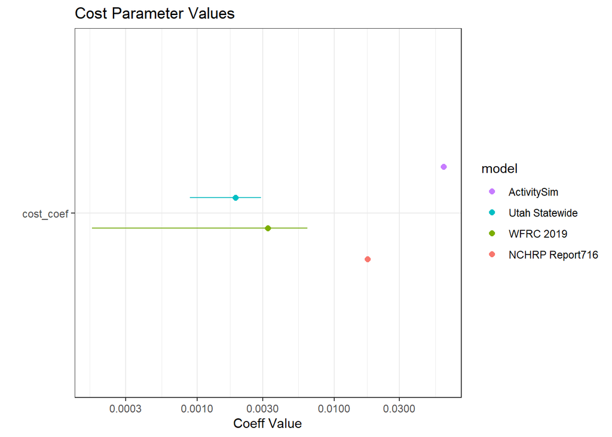